# Tareita de Métodos Numéricos 17-10-2025

Diana Laura Pais Felipe Matrícula:23-002-0030

17 octubre, 2025

```r
N <- 1000
a <- -10
b <- 10
paso <- 0.01
x <- seq(a,b,paso); (x)
```

[output not shown]

[output cut: 186 more lines]

```r
head(x,10)
```

```
##  [1] -10.00  -9.99  -9.98  -9.97  -9.96  -9.95  -9.94  -9.93  -9.92  -9.91
```

# Función

$f(x)=x^{2}-5x+6$

## Gráfico de la función

Graficamos la función cuadrática de $f(x)=x^{2}-5x+6$

```r
A <- 0
B <- 1
C <- -5
D <- 6

f_x <- A*(x^3)+B*(x^2)+C*x+D
head(f_x,10)
```

```
##  [1] 156.0000 155.7501 155.5004 155.2509 155.0016 154.7525 154.5036 154.2549
##  [9] 154.0064 153.7581
```

Graficamos la función

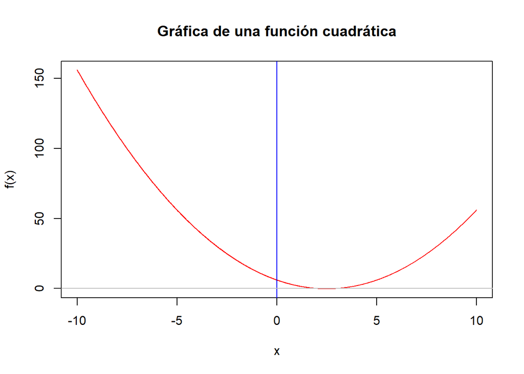

```r
plot(x,f_x, col = "red",
     main = "Gráfica de una función cuadrática",
     type = "l",
     xlab = "x",
     ylab = "f(x)")
abline(v = 0, type = "-", col = "blue")
abline(h = 0, type = "-", col = "gray")
```

Búsqueda de la raíz, después de revisar la gráfica, en el intervalo $[1,2.5]$

```r
a <- 1
b <- 2.5
```

Empezamos con el método de bisección: $c=\frac{a+b}{2}$

## Iteración 1

```r
c <- (a + b) / 2;
print(c)
```

```
## [1] 1.75
```

Definimos la función $\textit{f cuadrática}$ para evaluar nuestra cuadrática en los puntos de interés

```r
f_cuadratica <- function(x){
  A*(x^3)+B*(x^2)+(C*x)+D
}
```

Evaluamos nuestra función, en R, en los puntos $a$ y $b$

```r
fa <- f_cuadratica(a); print(fa)
```

```
## [1] 2
```

```r
fb <- f_cuadratica(b); print(fb)
```

```
## [1] -0.25
```

```r
fc <- f_cuadratica(c); print(fc)
```

```
## [1] 0.3125
```

```r
signo_fafc <- sign(fa*fc); print(signo_fafc)
```

```
## [1] 1
```

```r
signo_fbfc <- sign(fb*fc); print(signo_fbfc)
```

```
## [1] -1
```

```r
error <- (a - b) / 2; print(error)
```

```
## [1] -0.75
```

Como $fb*fc<0$ y $fa*fc>0$ hacemos la asignación $a\leftarrow c$, y calculamos el nuevo valor de $c$

## Iteración 2

```r
a <- c; print(a)
```

```
## [1] 1.75
```

```r
c <- (a+b) / 2; print(c)
```

```
## [1] 2.125
```

Evaluamos nuevamente la cuadrática en $a$, $b$ y $c$

```r
fa <- f_cuadratica(a); print(fa)
```

```
## [1] 0.3125
```

```r
fb <- f_cuadratica(b); print(fb)
```

```
## [1] -0.25
```

```r
fc <- f_cuadratica(c); print(fc)
```

```
## [1] -0.109375
```

```r
signo_fafc <- sign(fa*fc); print(signo_fafc)
```

```
## [1] -1
```

```r
signo_fbfc <- sign(fb*fc); print(signo_fbfc)
```

```
## [1] 1
```

```r
error <- (a - b) / 2; print(error)
```

```
## [1] -0.375
```

Como $fa*fc<0$ y $fb*fc>0$ hacemos la asignación $b\leftarrow c$, y calculamos el nuevo valor de $c$

## Iteración 3

```r
b <- c; print(b)
```

```
## [1] 2.125
```

```r
c <- (a+b) / 2; print(c)
```

```
## [1] 1.9375
```

Evaluamos nuevamente la cuadrática en $a$, $b$ y $c$

```r
fa <- f_cuadratica(a); print(fa)
```

```
## [1] 0.3125
```

```r
fb <- f_cuadratica(b); print(fb)
```

```
## [1] -0.109375
```

```r
fc <- f_cuadratica(c); print(fc)
```

```
## [1] 0.06640625
```

```r
signo_fafc <- sign(fa*fc); print(signo_fafc)
```

```
## [1] 1
```

```r
signo_fbfc <- sign(fb*fc); print(signo_fbfc)
```

```
## [1] -1
```

```r
error <- (a - b) / 2; print(error)
```

```
## [1] -0.1875
```

Como $fb*fc<0$ y $fa*fc>0$ hacemos la asignación $a\leftarrow c$, y calculamos el nuevo valor de $c$

## Iteración 4

```r
a <- c; print(a)
```

```
## [1] 1.9375
```

```r
c <- (a+b) / 2; print(c)
```

```
## [1] 2.03125
```

Evaluamos nuevamente la cuadrática en $a$, $b$ y $c$

```r
fa <- f_cuadratica(a); print(fa)
```

```
## [1] 0.06640625
```

```r
fb <- f_cuadratica(b); print(fb)
```

```
## [1] -0.109375
```

```r
fc <- f_cuadratica(c); print(fc)
```

```
## [1] -0.03027344
```

```r
signo_fafc <- sign(fa*fc); print(signo_fafc)
```

```
## [1] -1
```

```r
signo_fbfc <- sign(fb*fc); print(signo_fbfc)
```

```
## [1] 1
```

```r
error <- (a - b) / 2; print(error)
```

```
## [1] -0.09375
```

Evaluamos nuevamente la cuadrática en $a$, $b$ y $c$

```r
fa <- f_cuadratica(a); print(fa)
```

```
## [1] 0.06640625
```

```r
fb <- f_cuadratica(b); print(fb)
```

```
## [1] -0.109375
```

```r
fc <- f_cuadratica(c); print(fc)
```

```
## [1] -0.03027344
```

```r
signo_fafc <- sign(fa*fc); print(signo_fafc)
```

```
## [1] -1
```

```r
signo_fbfc <- sign(fb*fc); print(signo_fbfc)
```

```
## [1] 1
```

```r
error <- (a - b) / 2; print(error)
```

```
## [1] -0.09375
```

Como $fa*fc<0$ y $fb*fc>0$ hacemos la asignación $b\leftarrow c$, y calculamos el nuevo valor de $c$

## Iteración 5

```r
b <- c; print(b)
```

```
## [1] 2.03125
```

```r
c <- (a+b) / 2; print(c)
```

```
## [1] 1.984375
```

Evaluamos nuevamente la cuadrática en $a$, $b$ y $c$

```r
fa <- f_cuadratica(a); print(fa)
```

```
## [1] 0.06640625
```

```r
fb <- f_cuadratica(b); print(fb)
```

```
## [1] -0.03027344
```

```r
fc <- f_cuadratica(c); print(fc)
```

```
## [1] 0.01586914
```

```r
signo_fafc <- sign(fa*fc); print(signo_fafc)
```

```
## [1] 1
```

```r
signo_fbfc <- sign(fb*fc); print(signo_fbfc)
```

```
## [1] -1
```

```r
error <- (a - b) / 2; print(error)
```

```
## [1] -0.046875
```

Como $fb*fc<0$ y $fa*fc>0$ hacemos la asignación $a\leftarrow c$, y calculamos el nuevo valor de $c$

## Iteración 6

```r
a <- c; print(a)
```

```
## [1] 1.984375
```

```r
c <- (a+b) / 2; print(c)
```

```
## [1] 2.007812
```

Evaluamos nuevamente la cuadrática en $a$, $b$ y $c$

```r
fa <- f_cuadratica(a); print(fa)
```

```
## [1] 0.01586914
```

```r
fb <- f_cuadratica(b); print(fb)
```

```
## [1] -0.03027344
```

```r
fc <- f_cuadratica(c); print(fc)
```

```
## [1] -0.007751465
```

```r
signo_fafc <- sign(fa*fc); print(signo_fafc)
```

```
## [1] -1
```

```r
signo_fbfc <- sign(fb*fc); print(signo_fbfc)
```

```
## [1] 1
```

```r
error <- (a - b) / 2; print(error)
```

```
## [1] -0.0234375
```

Como $fa*fc<0$ y $fb*fc>0$ hacemos la asignación $b\leftarrow c$, y calculamos el nuevo valor de $c$

## Iteración 7

```r
b <- c; print(b)
```

```
## [1] 2.007812
```

```r
c <- (a+b) / 2; print(c)
```

```
## [1] 1.996094
```

Evaluamos nuevamente la cuadrática en $a$, $b$ y $c$

```r
fa <- f_cuadratica(a); print(fa)
```

```
## [1] 0.01586914
```

```r
fb <- f_cuadratica(b); print(fb)
```

```
## [1] -0.007751465
```

```r
fc <- f_cuadratica(c); print(fc)
```

```
## [1] 0.003921509
```

```r
signo_fafc <- sign(fa*fc); print(signo_fafc)
```

```
## [1] 1
```

```r
signo_fbfc <- sign(fb*fc); print(signo_fbfc)
```

```
## [1] -1
```

```r
error <- (a - b) / 2; print(error)
```

```
## [1] -0.01171875
```

Como $fb*fc<0$ y $fa*fc>0$ hacemos la asignación $a\leftarrow c$, y calculamos el nuevo valor de $c$

```r
a <- c; print(a)
```

```
## [1] 1.996094
```

```r
c <- (a+b) / 2; print(c)
```

```
## [1] 2.001953
```

Evaluamos nuevamente la cuadrática en $a$, $b$ y $c$

```r
fa <- f_cuadratica(a); print(fa)
```

```
## [1] 0.003921509
```

```r
fb <- f_cuadratica(b); print(fb)
```

```
## [1] -0.007751465
```

```r
fc <- f_cuadratica(c); print(fc)
```

```
## [1] -0.00194931
```

```r
signo_fafc <- sign(fa*fc); print(signo_fafc)
```

```
## [1] -1
```

```r
signo_fbfc <- sign(fb*fc); print(signo_fbfc)
```

```
## [1] 1
```

```r
error <- (a - b) / 2; print(error)
```

```
## [1] -0.005859375
```

Como $fa*fc<0$ y $fb*fc>0$ hacemos la asignación $b\leftarrow c$, y calculamos el nuevo valor de $c$

## Iteración 10

```r
b <- c; print(b)
```

```
## [1] 2.001953
```

```r
c <- (a+b) / 2; print(c)
```

```
## [1] 1.999023
```

Evaluamos nuevamente la cuadrática en $a$, $b$ y $c$

```r
fa <- f_cuadratica(a); print(fa)
```

```
## [1] 0.003921509
```

```r
fb <- f_cuadratica(b); print(fb)
```

```
## [1] -0.00194931
```

```r
fc <- f_cuadratica(c); print(fc)
```

```
## [1] 0.0009775162
```

```r
signo_fafc <- sign(fa*fc); print(signo_fafc)
```

```
## [1] 1
```

```r
signo_fbfc <- sign(fb*fc); print(signo_fbfc)
```

```
## [1] -1
```

```r
error <- (a - b) / 2; print(error)
```

```
## [1] -0.002929688
```

Como $fb*fc<0$ y $fa*fc>0$ hacemos la asignación $a\leftarrow c$, y calculamos el nuevo valor de $c$

## Iteración 11

```r
a <- c; print(a)
```

```
## [1] 1.999023
```

```r
c <- (a+b) / 2; print(c)
```

```
## [1] 2.000488
```

Evaluamos nuevamente la cuadrática en $a$, $b$ y $c$

```r
fa <- f_cuadratica(a); print(fa)
```

```
## [1] 0.0009775162
```

```r
fb <- f_cuadratica(b); print(fb)
```

```
## [1] -0.00194931
```

```r
fc <- f_cuadratica(c); print(fc)
```

```
## [1] -0.0004880428
```

```r
signo_fafc <- sign(fa*fc); print(signo_fafc)
```

```
## [1] -1
```

```r
signo_fbfc <- sign(fb*fc); print(signo_fbfc)
```

```
## [1] 1
```

```r
error <- (a - b) / 2; print(error)
```

```
## [1] -0.001464844
```

Como $fa*fc<0$ y $fb*fc>0$ hacemos la asignación $b\leftarrow c$, y calculamos el nuevo valor de $c$

## Iteración 12

```r
b <- c; print(b)
```

```
## [1] 2.000488
```

```r
c <- (a+b) / 2; print(c)
```

```
## [1] 1.999756
```

Evaluamos nuevamente la cuadrática en $a$, $b$ y $c$

```r
fa <- f_cuadratica(a); print(fa)
```

```
## [1] 0.0009775162
```

```r
fb <- f_cuadratica(b); print(fb)
```

```
## [1] -0.0004880428
```

```r
fc <- f_cuadratica(c); print(fc)
```

```
## [1] 0.0002442002
```

```r
signo_fafc <- sign(fa*fc); print(signo_fafc)
```

```
## [1] 1
```

```r
signo_fbfc <- sign(fb*fc); print(signo_fbfc)
```

```
## [1] -1
```

```r
error <- (a - b) / 2; print(error)
```

```
## [1] -0.0007324219
```

Como $fb*fc<0$ y $fa*fc>0$ hacemos la asignación $a\leftarrow c$, y calculamos el nuevo valor de $c$

## Iteración 13

```r
a <- c; print(a)
```

```
## [1] 1.999756
```

```r
c <- (a+b) / 2; print(c)
```

```
## [1] 2.000122
```

Evaluamos nuevamente la cuadrática en $a$, $b$ y $c$

```r
fa <- f_cuadratica(a); print(fa)
```

```
## [1] 0.0002442002
```

```r
fb <- f_cuadratica(b); print(fb)
```

```
## [1] -0.0004880428
```

```r
fc <- f_cuadratica(c); print(fc)
```

```
## [1] -0.0001220554
```

```r
signo_fafc <- sign(fa*fc); print(signo_fafc)
```

```
## [1] -1
```

```r
signo_fbfc <- sign(fb*fc); print(signo_fbfc)
```

```
## [1] 1
```

```r
error <- (a - b) / 2; print(error)
```

```
## [1] -0.0003662109
```

Como $fa*fc<0$ y $fb*fc>0$ hacemos la asignación $b\leftarrow c$, y calculamos el nuevo valor de $c$

## Iteración 14

```r
b <- c; print(b)
```

```
## [1] 2.000122
```

```r
c <- (a+b) / 2; print(c)
```

```
## [1] 1.999939
```

Evaluamos nuevamente la cuadrática en $a$, $b$ y $c$

```r
fa <- f_cuadratica(a); print(fa)
```

```
## [1] 0.0002442002
```

```r
fb <- f_cuadratica(b); print(fb)
```

```
## [1] -0.0001220554
```

```r
fc <- f_cuadratica(c); print(fc)
```

```
## [1] 6.103888e-05
```

```r
signo_fafc <- sign(fa*fc); print(signo_fafc)
```

```
## [1] 1
```

```r
signo_fbfc <- sign(fb*fc); print(signo_fbfc)
```

```
## [1] -1
```

```r
error <- (a - b) / 2; print(error)
```

```
## [1] -0.0001831055
```

Como $fb*fc<0$ y $fa*fc>0$ hacemos la asignación $a\leftarrow c$, y calculamos el nuevo valor de $c$

## Iteración 15

```r
a <- c; print(a)
```

```
## [1] 1.999939
```

```r
c <- (a+b) / 2; print(c)
```

```
## [1] 2.000031
```

Evaluamos nuevamente la cuadrática en $a$, $b$ y $c$

```r
fa <- f_cuadratica(a); print(fa)
```

```
## [1] 6.103888e-05
```

```r
fb <- f_cuadratica(b); print(fb)
```

```
## [1] -0.0001220554
```

```r
fc <- f_cuadratica(c); print(fc)
```

```
## [1] -3.051665e-05
```

```r
signo_fafc <- sign(fa*fc); print(signo_fafc)
```

```
## [1] -1
```

```r
signo_fbfc <- sign(fb*fc); print(signo_fbfc)
```

```
## [1] 1
```

```r
error <- (a - b) / 2; print(error)
```

```
## [1] -9.155273e-05
```

Como $fa*fc<0$ y $fb*fc>0$ hacemos la asignación $b\leftarrow c$, y calculamos el nuevo valor de $c$

## Iteración 16

```r
b <- c; print(b)
```

```
## [1] 2.000031
```

```r
c <- (a+b) / 2; print(c)
```

```
## [1] 1.999985
```

Evaluamos nuevamente la cuadrática en $a$, $b$ y $c$

```r
fa <- f_cuadratica(a); print(fa)
```

```
## [1] 6.103888e-05
```

```r
fb <- f_cuadratica(b); print(fb)
```

```
## [1] -3.051665e-05
```

```r
fc <- f_cuadratica(c); print(fc)
```

```
## [1] 1.525902e-05
```

```r
signo_fafc <- sign(fa*fc); print(signo_fafc)
```

```
## [1] 1
```

```r
signo_fbfc <- sign(fb*fc); print(signo_fbfc)
```

```
## [1] -1
```

```r
error <- (a - b) / 2; print(error)
```

```
## [1] -4.577637e-05
```

Como $fb*fc<0$ y $fa*fc>0$ hacemos la asignación $a\leftarrow c$, y calculamos el nuevo valor de $c$

## Iteración 17

```r
a <- c; print(a)
```

```
## [1] 1.999985
```

```r
c <- (a+b) / 2; print(c)
```

```
## [1] 2.000008
```

Evaluamos nuevamente la cuadrática en $a$, $b$ y $c$

```r
fa <- f_cuadratica(a); print(fa)
```

```
## [1] 1.525902e-05
```

```r
fb <- f_cuadratica(b); print(fb)
```

```
## [1] -3.051665e-05
```

```r
fc <- f_cuadratica(c); print(fc)
```

```
## [1] -7.629336e-06
```

```r
signo_fafc <- sign(fa*fc); print(signo_fafc)
```

```
## [1] -1
```

```r
signo_fbfc <- sign(fb*fc); print(signo_fbfc)
```

```
## [1] 1
```

```r
error <- (a - b) / 2; print(error)
```

```
## [1] -2.288818e-05
```

Como $fa*fc<0$ y $fb*fc>0$ hacemos la asignación $b\leftarrow c$, y calculamos el nuevo valor de $c$

## Iteración 18

```r
b <- c; print(b)
```

```
## [1] 2.000008
```

```r
c <- (a+b) / 2; print(c)
```

```
## [1] 1.999996
```

Evaluamos nuevamente la cuadrática en $a$, $b$ y $c$

```r
fa <- f_cuadratica(a); print(fa)
```

```
## [1] 1.525902e-05
```

```r
fb <- f_cuadratica(b); print(fb)
```

```
## [1] -7.629336e-06
```

```r
fc <- f_cuadratica(c); print(fc)
```

```
## [1] 3.814712e-06
```

```r
signo_fafc <- sign(fa*fc); print(signo_fafc)
```

```
## [1] 1
```

```r
signo_fbfc <- sign(fb*fc); print(signo_fbfc)
```

```
## [1] -1
```

```r
error <- (a - b) / 2; print(error)
```

```
## [1] -1.144409e-05
```

Como $fb*fc<0$ y $fa*fc>0$ hacemos la asignación $a\leftarrow c$, y calculamos el nuevo valor de $c$

## Iteración 19

```r
a <- c; print(a)
```

```
## [1] 1.999996
```

```r
c <- (a+b) / 2; print(c)
```

```
## [1] 2.000002
```

Evaluamos nuevamente la cuadrática en $a$, $b$ y $c$

```r
fa <- f_cuadratica(a); print(fa)
```

```
## [1] 3.814712e-06
```

```r
fb <- f_cuadratica(b); print(fb)
```

```
## [1] -7.629336e-06
```

```r
fc <- f_cuadratica(c); print(fc)
```

```
## [1] -1.907345e-06
```

```r
signo_fafc <- sign(fa*fc); print(signo_fafc)
```

```
## [1] -1
```

```r
signo_fbfc <- sign(fb*fc); print(signo_fbfc)
```

```
## [1] 1
```

```r
error <- (a - b) / 2; print(error)
```

```
## [1] -5.722046e-06
```

Como $fa*fc<0$ y $fb*fc>0$ hacemos la asignación $b\leftarrow c$, y calculamos el nuevo valor de $c$

## Iteración 20

```r
b <- c; print(b)
```

```
## [1] 2.000002
```

```r
c <- (a+b) / 2; print(c)
```

```
## [1] 1.999999
```

Evaluamos nuevamente la cuadrática en $a$, $b$ y $c$

```r
fa <- f_cuadratica(a); print(fa)
```

```
## [1] 3.814712e-06
```

```r
fb <- f_cuadratica(b); print(fb)
```

```
## [1] -1.907345e-06
```

```r
fc <- f_cuadratica(c); print(fc)
```

```
## [1] 9.536752e-07
```

```r
signo_fafc <- sign(fa*fc); print(signo_fafc)
```

```
## [1] 1
```

```r
signo_fbfc <- sign(fb*fc); print(signo_fbfc)
```

```
## [1] -1
```

```r
error <- (a - b) / 2; print(error)
```

```
## [1] -2.861023e-06
```

## Iteración 21

```r
a <- c; print(a)
```

```
## [1] 1.999999
```

```r
c <- (a+b) / 2; print(c)
```

```
## [1] 2
```

Evaluamos nuevamente la cuadrática en $a$, $b$ y $c$

```r
fa <- f_cuadratica(a); print(fa)
```

```
## [1] 9.536752e-07
```

```r
fb <- f_cuadratica(b); print(fb)
```

```
## [1] -1.907345e-06
```

```r
fc <- f_cuadratica(c); print(fc)
```

```
## [1] -4.768369e-07
```

```r
signo_fafc <- sign(fa*fc); print(signo_fafc)
```

```
## [1] -1
```

```r
signo_fbfc <- sign(fb*fc); print(signo_fbfc)
```

```
## [1] 1
```

```r
error <- (a - b) / 2; print(error)
```

```
## [1] -1.430511e-06
```

Como $fa*fc<0$ y $fb*fc>0$ hacemos la asignación $b\leftarrow c$, y calculamos el nuevo valor de $c$

## Iteración 22

```r
b <- c; print(b)
```

```
## [1] 2
```

```r
c <- (a+b) / 2; print(c)
```

```
## [1] 2
```

Evaluamos nuevamente la cuadrática en $a$, $b$ y $c$

```r
fa <- f_cuadratica(a); print(fa)
```

```
## [1] 9.536752e-07
```

```r
fb <- f_cuadratica(b); print(fb)
```

```
## [1] -4.768369e-07
```

```r
fc <- f_cuadratica(c); print(fc)
```

```
## [1] 2.384186e-07
```

```r
signo_fafc <- sign(fa*fc); print(signo_fafc)
```

```
## [1] 1
```

```r
signo_fbfc <- sign(fb*fc); print(signo_fbfc)
```

```
## [1] -1
```

```r
error <- (a - b) / 2; print(error)
```

```
## [1] -7.152557e-07
```

# Resulado

En las iteraciones $21$ y $22$, se observa que el valor de $c$ es $2$ además de que el error presentado es mínimo, por lo cual se puede decir que: el resultado de una de las raíces en el intervalo dado es $2$.